# Handwritten

**Handwritten Digit Recognition (MNIST)**

**Introduction:-** Handwritten Digit Recognition is a classic deep learning problem that demonstrates the power of neural networks in visual pattern recognition. The project aims to classify handwritten digits (0–9) from image data using the MNIST dataset. This dataset contains thousands of grayscale images of handwritten digits, serving as a benchmark for computer vision algorithms. By training a neural network model, we enable a machine to automatically learn and identify digit patterns, thereby simulating a human-like ability to read handwritten numbers. This project builds foundational understanding in deep learning, including neural architecture design, activation functions, optimization, and performance evaluation.

**Business Problem:-** Handwritten Digit Recognition is a classic deep learning problem that demonstrates the power of neural networks in visual pattern recognition. The project aims to classify handwritten digits (0–9) from image data using the MNIST dataset. This dataset contains thousands of grayscale images of handwritten digits, serving as a benchmark for computer vision algorithms. By training a neural network model, we enable a machine to automatically learn and identify digit patterns, thereby simulating a human-like ability to read handwritten numbers. This project builds foundational understanding in deep learning, including neural architecture design, activation functions, optimization, and performance evaluation.

**Problem Statement:- The goal of this project is to design and train a machine learning model capable of accurately identifying handwritten digits (0–9) from grayscale images. Using the MNIST dataset, we aim to build a neural network that can generalize across different handwriting styles while maintaining high accuracy and low computational cost. The system should be efficient enough to serve as a foundation for real-world applications such as automated form processing, cheque recognition, and document digitization.**

This section imports all the essential libraries required for the Handwritten Digit Recognition (MNIST) project. NumPy and Pandas handle numerical operations and data manipulation, while Matplotlib and Seaborn are used for visualizing data trends and model performance. Scikit-learn utilities like train_test_split, cross_val_score, and GridSearchCV assist in model evaluation and hyperparameter tuning. The deep learning framework TensorFlow/Keras provides tools to load the MNIST dataset, build the neural network using Sequential, Dense, and Dropout layers, and prepare labels through to_categorical. Warnings are suppressed for cleaner outputs, and Seaborn’s aesthetic settings enhance visualization. Finally, a confirmation message ensures all libraries are successfully imported and the environment is ready for modeling.

```python
# Data Handling & Computation
import numpy as np
import pandas as pd

# Data Visualization
import matplotlib.pyplot as plt
import seaborn as sns

# Machine Learning Utilities
from sklearn.model_selection import train_test_split, KFold, cross_val_score, GridSearchCV
from sklearn.metrics import confusion_matrix, classification_report

# Deep Learning Framework
from tensorflow.keras.datasets import mnist
from tensorflow.keras.models import Sequential, load_model
from tensorflow.keras.layers import Dense, Dropout
from tensorflow.keras.utils import to_categorical

# Warnings & Aesthetic Settings
import warnings
warnings.filterwarnings("ignore")
sns.set_style("whitegrid")

# Confirm successful imports
print(" All libraries imported successfully!")
```

```
 All libraries imported successfully!
```

This section loads the MNIST dataset, a well-known collection of handwritten digit images used for training and evaluating image classification models. It splits the data into training and testing sets, displaying their respective shapes to confirm successful loading. Each image is represented as a 28×28 grayscale matrix, and the corresponding labels indicate digits (0–9). To provide a quick tabular preview, the training images are flattened into one-dimensional arrays and converted into a Pandas DataFrame, allowing the first five samples to be displayed in a familiar, spreadsheet-like format. This step helps verify that the dataset is properly structured and ready for preprocessing.

```python
# Load MNIST dataset
(X_train, y_train), (X_test, y_test) = mnist.load_data()

# Display dataset shapes
print(" MNIST Dataset Loaded Successfully!")
print(f"Training Data Shape: {X_train.shape}")
print(f"Training Labels Shape: {y_train.shape}")
print(f"Testing Data Shape: {X_test.shape}")
print(f"Testing Labels Shape: {y_test.shape}")

# Convert a few training images into a DataFrame (flattened for head-like display)
X_train_flat = X_train.reshape(X_train.shape[0], -1)
df_preview = pd.DataFrame(X_train_flat)

# Display first 5 rows (like .head())
print("\n Preview of first 5 training samples (flattened):")
print(df_preview.head())
```

```
Downloading data from https://storage.googleapis.com/tensorflow/tf-keras-datasets/mnist.npz
11490434/11490434 ━━━━━━━━━━━━━━━━━━━━ 1s 0us/step
 MNIST Dataset Loaded Successfully!
Training Data Shape: (60000, 28, 28)
Training Labels Shape: (60000,)
Testing Data Shape: (10000, 28, 28)
Testing Labels Shape: (10000,)

 Preview of first 5 training samples (flattened):
   0    1    2    3    4    5    6    7    8    9    ...  774  775  776  777  \
0    0    0    0    0    0    0    0    0    0    0  ...    0    0    0    0
1    0    0    0    0    0    0    0    0    0    0  ...    0    0    0    0
2    0    0    0    0    0    0    0    0    0    0  ...    0    0    0    0
3    0    0    0    0    0    0    0    0    0    0  ...    0    0    0    0
4    0    0    0    0    0    0    0    0    0    0  ...    0    0    0    0

   778  779  780  781  782  783
0    0    0    0    0    0    0
1    0    0    0    0    0    0
2    0    0    0    0    0    0
3    0    0    0    0    0    0
4    0    0    0    0    0    0

[5 rows x 784 columns]
```

This section visualizes a sample of handwritten digits from the MNIST training dataset to help understand the data before model training. Using Matplotlib, it displays the first nine images in a 3×3 grid, where each image represents a handwritten digit (0–9) shown in grayscale. The corresponding true label is displayed as the title above each image. This visualization step provides an intuitive look at the dataset, confirming that the images are correctly loaded and labeled for further processing and modeling.

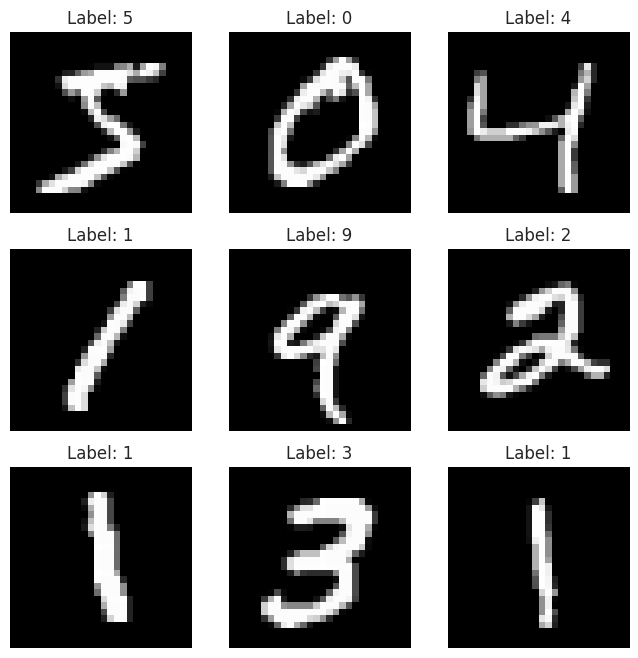

```python
plt.figure(figsize=(8, 8))
for i in range(9):
    plt.subplot(3, 3, i + 1)
    plt.imshow(X_train[i], cmap='gray')
    plt.title(f"Label: {y_train[i]}")
    plt.axis('off')
plt.show()
```

This code converts the first 1000 images from the MNIST training dataset into a pandas DataFrame for easy exploration and analysis. Each image (28×28 pixels) is flattened into a single row containing 784 pixel values, and a new column named ‘label’ is added to represent the corresponding digit (0–9). This structured format allows you to perform operations like correlation analysis, summary statistics, and visualization using standard data analysis tools such as pandas and seaborn.

```python
# Convert first 1000 images into DataFrame for exploration
X_df = pd.DataFrame(X_train[:1000].reshape(1000, -1))
X_df['label'] = y_train[:1000]
```

```python
print(X_df.info())
```

```
<class 'pandas.core.frame.DataFrame'>
RangeIndex: 1000 entries, 0 to 999
Columns: 785 entries, 0 to label
dtypes: uint8(785)
memory usage: 766.7 KB
None
```

The descriptive statistics of the dataset show that each image consists of 784 pixel values representing grayscale intensities ranging from 0 (black) to 255 (white). Most pixel values are close to zero, indicating that a large portion of the image area is blank background. The label column, which represents the digits 0 to 9, has a mean value of approximately 4.45, suggesting a balanced distribution of digits across the dataset. Overall, the dataset is clean, numeric, and well-structured, making it ready for normalization and further model training.

```python
print(X_df.describe())
```

```
            0       1       2       3       4       5       6       7       8  \
count  1000.0  1000.0  1000.0  1000.0  1000.0  1000.0  1000.0  1000.0  1000.0
mean      0.0     0.0     0.0     0.0     0.0     0.0     0.0     0.0     0.0
std       0.0     0.0     0.0     0.0     0.0     0.0     0.0     0.0     0.0
min       0.0     0.0     0.0     0.0     0.0     0.0     0.0     0.0     0.0
25%       0.0     0.0     0.0     0.0     0.0     0.0     0.0     0.0     0.0
50%       0.0     0.0     0.0     0.0     0.0     0.0     0.0     0.0     0.0
75%       0.0     0.0     0.0     0.0     0.0     0.0     0.0     0.0     0.0
max       0.0     0.0     0.0     0.0     0.0     0.0     0.0     0.0     0.0

            9  ...          775     776     777     778     779     780  \
count  1000.0  ...  1000.000000  1000.0  1000.0  1000.0  1000.0  1000.0
mean      0.0  ...     0.110000     0.0     0.0     0.0     0.0     0.0
std       0.0  ...     3.478505     0.0     0.0     0.0     0.0     0.0
min       0.0  ...     0.000000     0.0     0.0     0.0     0.0     0.0
25%       0.0  ...     0.000000     0.0     0.0     0.0     0.0     0.0
50%       0.0  ...     0.000000     0.0     0.0     0.0     0.0     0.0
75%       0.0  ...     0.000000     0.0     0.0     0.0     0.0     0.0
max       0.0  ...   110.000000     0.0     0.0     0.0     0.0     0.0

          781     782     783        label
count  1000.0  1000.0  1000.0  1000.000000
mean      0.0     0.0     0.0     4.452000
std       0.0     0.0     0.0     2.881319
min       0.0     0.0     0.0     0.000000
25%       0.0     0.0     0.0     2.000000
50%       0.0     0.0     0.0     4.000000
75%       0.0     0.0     0.0     7.000000
max       0.0     0.0     0.0     9.000000

[8 rows x 785 columns]
```

```python
print("Missing values:", X_df.isnull().sum().sum())
```

```
Missing values: 0
```

This code generates a correlation heatmap to analyze relationships between the pixel values and the digit labels in the MNIST dataset.

The corr() function computes pairwise correlations between all features (pixels) and the label column. Since most pixel values are sparse (close to zero), correlations between pixels are generally low, indicating minimal redundancy among them. The heatmap visually represents these relationships, where the color intensity (from blue to red) highlights the strength and direction of correlation.

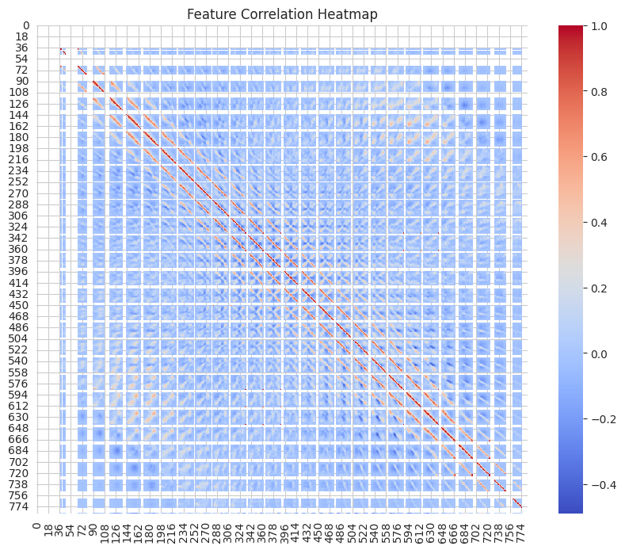

```python
corr = X_df.corr()
plt.figure(figsize=(10, 8))
sns.heatmap(corr, cmap='coolwarm')
plt.title('Feature Correlation Heatmap')
plt.show()
```

By flattening (ravel()) all pixel values into a single array and plotting them as a histogram, we can observe how frequently each pixel intensity (ranging from 0 to 255) occurs. The histogram typically shows that most pixel values are near 0, indicating that the majority of the image background is black, while a smaller number of pixels have higher intensities (closer to 255), representing the white strokes of handwritten digits.

This visualization helps understand the contrast and sparsity of the dataset — confirming that normalization (scaling pixel values between 0 and 1) is necessary for better neural network performance.

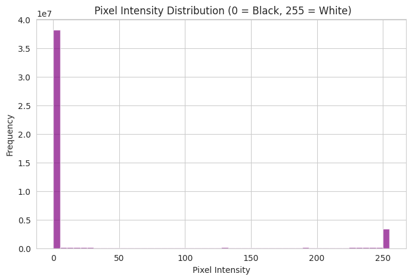

```python
plt.figure(figsize=(8, 5))
plt.hist(X_train.ravel(), bins=50, color='purple', alpha=0.7)
plt.title(" Pixel Intensity Distribution (0 = Black, 255 = White)")
plt.xlabel("Pixel Intensity")
plt.ylabel("Frequency")
plt.show()
```

This step normalizes the image data by scaling pixel values from the range 0–255 to 0–1. Normalization helps the neural network train faster and more effectively by ensuring all inputs are on a consistent scale, leading to better model performance and stability.

```python
X_train = X_train / 255.0
X_test = X_test / 255.0
```

This step flattens each 28×28 image into a 1D array of 784 pixels, preparing the data for input into a feedforward neural network. Since dense layers in neural networks expect 1D input vectors, this reshaping converts the 2D image structure into a suitable format for training.

```python
X_train = X_train.reshape(-1, 784)
X_test = X_test.reshape(-1, 784)
```

This step converts the numeric class labels (0–9) into one-hot encoded vectors using to_categorical(). In this format, each label is represented as a binary vector of length 10, where only the index corresponding to the actual digit is marked as 1. This encoding is essential for multiclass classification, allowing the neural network to output probabilities for all 10 classes.

```python
from tensorflow.keras.utils import to_categorical
y_train = to_categorical(y_train, 10)
y_test = to_categorical(y_test, 10)
```

**Model Building — Feedforward Neural Network (FNN)**

In this step, we build a Feedforward Neural Network (FNN) using Keras’ Sequential model. It consists of:

1. Input Layer: Takes 784 input features (flattened 28×28 pixel images).
2. Hidden Layers: Two dense layers with 512 and 256 neurons, both using the ReLU activation for non-linearity.
3. Dropout Layers: Added after each hidden layer (rate = 0.2) to prevent overfitting by randomly disabling neurons during training.
4. Output Layer: A softmax layer with 10 neurons, corresponding to the 10 digit classes (0–9).

```python
from tensorflow.keras.models import Sequential
from tensorflow.keras.layers import Dense, Dropout

model = Sequential([
    Dense(512, activation='relu', input_shape=(784,)),
    Dropout(0.2),
    Dense(256, activation='relu'),
    Dropout(0.2),
    Dense(10, activation='softmax')
])

model.compile(
    optimizer='adam',
    loss='categorical_crossentropy',
    metrics=['accuracy']
)
```

**Model Training and Validation**

This step splits the normalized training data into two parts: a training subset and a validation subset. Using train_test_split, 20% of the data is set aside for validation, allowing the model’s performance to be monitored on unseen data during training. This helps detect overfitting early and ensures that the model generalizes well. The random_state=42 ensures reproducibility of the split.

```python
from sklearn.model_selection import train_test_split

X_train_part, X_val, y_train_part, y_val = train_test_split(
    X_train, y_train, test_size=0.2, random_state=42
)
```

In this step, the neural network model is trained using the training subset (X_train_part, y_train_part) for 15 epochs with a batch size of 128. During each epoch, the model learns patterns from the training data and evaluates its performance on the validation set (X_val, y_val). The fit() function records the training and validation loss and accuracy in the history object, which can later be used for visualizing learning progress and analyzing model performance over time.

```python
history = model.fit(
    X_train_part, y_train_part,
    epochs=15,
    batch_size=128,
    validation_data=(X_val, y_val)
)
```

```
375/375 ━━━━━━━━━━━━━━━━━━━━ 8s 16ms/step - accuracy: 0.8432 - loss: 0.5231 - val_accuracy: 0.9605 - val_loss: 0.1323
375/375 ━━━━━━━━━━━━━━━━━━━━ 7s 18ms/step - accuracy: 0.9633 - loss: 0.1223 - val_accuracy: 0.9737 - val_loss: 0.0881
375/375 ━━━━━━━━━━━━━━━━━━━━ 6s 15ms/step - accuracy: 0.9757 - loss: 0.0777 - val_accuracy: 0.9753 - val_loss: 0.0801
375/375 ━━━━━━━━━━━━━━━━━━━━ 7s 19ms/step - accuracy: 0.9809 - loss: 0.0593 - val_accuracy: 0.9777 - val_loss: 0.0755
375/375 ━━━━━━━━━━━━━━━━━━━━ 6s 15ms/step - accuracy: 0.9843 - loss: 0.0477 - val_accuracy: 0.9791 - val_loss: 0.0706
375/375 ━━━━━━━━━━━━━━━━━━━━ 7s 18ms/step - accuracy: 0.9888 - loss: 0.0372 - val_accuracy: 0.9793 - val_loss: 0.0734
375/375 ━━━━━━━━━━━━━━━━━━━━ 6s 16ms/step - accuracy: 0.9884 - loss: 0.0347 - val_accuracy: 0.9802 - val_loss: 0.0722
375/375 ━━━━━━━━━━━━━━━━━━━━ 11s 18ms/step - accuracy: 0.9892 - loss: 0.0322 - val_accuracy: 0.9823 - val_loss: 0.0704
375/375 ━━━━━━━━━━━━━━━━━━━━ 6s 16ms/step - accuracy: 0.9922 - loss: 0.0233 - val_accuracy: 0.9810 - val_loss: 0.0744
375/375 ━━━━━━━━━━━━━━━━━━━━ 7s 18ms/step - accuracy: 0.9925 - loss: 0.0231 - val_accuracy: 0.9822 - val_loss: 0.0689
375/375 ━━━━━━━━━━━━━━━━━━━━ 6s 15ms/step - accuracy: 0.9919 - loss: 0.0229 - val_accuracy: 0.9827 - val_loss: 0.0756
375/375 ━━━━━━━━━━━━━━━━━━━━ 7s 18ms/step - accuracy: 0.9941 - loss: 0.0188 - val_accuracy: 0.9813 - val_loss: 0.0764
375/375 ━━━━━━━━━━━━━━━━━━━━ 6s 15ms/step - accuracy: 0.9934 - loss: 0.0196 - val_accuracy: 0.9823 - val_loss: 0.0725
375/375 ━━━━━━━━━━━━━━━━━━━━ 7s 19ms/step - accuracy: 0.9942 - loss: 0.0183 - val_accuracy: 0.9822 - val_loss: 0.0835
375/375 ━━━━━━━━━━━━━━━━━━━━ 10s 18ms/step - accuracy: 0.9948 - loss: 0.0175 - val_accuracy: 0.9825 - val_loss: 0.0758
```

**Model Evaluation and Visualization**

This code visualizes how the model’s accuracy evolves during training and validation over each epoch. It creates a side-by-side subplot and plots two lines — one for training accuracy and another for validation accuracy — helping to observe how well the model is learning and generalizing. The plot titled “Model Accuracy” helps identify issues like overfitting (if validation accuracy diverges from training accuracy) or underfitting (if both accuracies remain low).

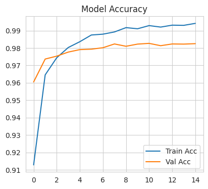

```python
plt.figure(figsize=(10, 4))

plt.subplot(1, 2, 1)
plt.plot(history.history['accuracy'], label='Train Acc')
plt.plot(history.history['val_accuracy'], label='Val Acc')
plt.legend()
plt.title('Model Accuracy')
```

This code plots the training and validation loss curves to visualize how the model’s error changes over time. It shows two lines — one for training loss and another for validation loss — across all epochs. The “Model Loss” graph helps assess the model’s convergence and detect issues like overfitting (if validation loss starts increasing while training loss decreases) or underfitting (if both losses remain high).

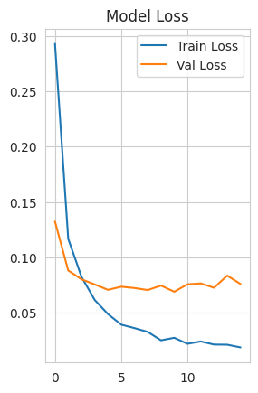

```python
plt.subplot(1, 2, 2)
plt.plot(history.history['loss'], label='Train Loss')
plt.plot(history.history['val_loss'], label='Val Loss')
plt.legend()
plt.title('Model Loss')
plt.show()
```

**Evaluate on Test Set:**

```python
test_loss, test_acc = model.evaluate(X_test, y_test)
print(f"Test Accuracy: {test_acc:.4f}")
```

```
313/313 ━━━━━━━━━━━━━━━━━━━━ 1s 3ms/step - accuracy: 0.9786 - loss: 0.0914
Test Accuracy: 0.9822
```

```python
model.save("mnist_ffn_model.keras")
from tensorflow.keras.models import load_model
loaded_model = load_model("mnist_ffn_model.keras")
```

This code is used to visualize the model’s prediction results on the MNIST test dataset. First, the trained model generates predictions for all test images, identifying the most likely digit for each image using np.argmax(). The true labels are also extracted for comparison. Then, a 3×3 grid of images is plotted, displaying each handwritten digit alongside its predicted and actual label. This visualization helps assess how accurately the model recognizes digits and provides an intuitive way to spot any incorrect classifications.

```
313/313 ━━━━━━━━━━━━━━━━━━━━ 1s 3ms/step
```

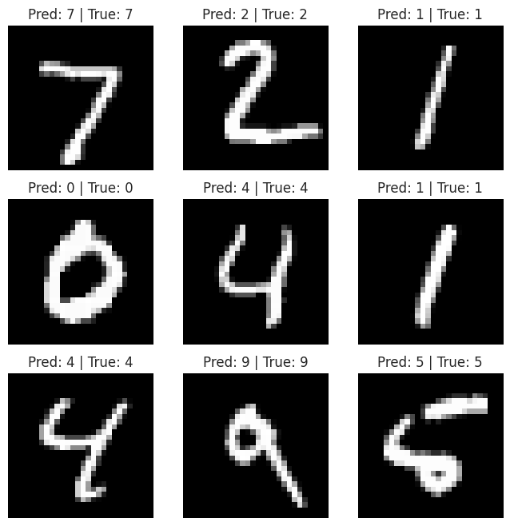

```python
predictions = loaded_model.predict(X_test)
predicted_labels = np.argmax(predictions, axis=1)
true_labels = np.argmax(y_test, axis=1)

# Visualize some results
plt.figure(figsize=(8, 8))
for i in range(9):
    plt.subplot(3, 3, i + 1)
    plt.imshow(X_test[i].reshape(28, 28), cmap='gray')
    plt.title(f"Pred: {predicted_labels[i]} | True: {true_labels[i]}")
    plt.axis('off')
plt.show()
```

This code evaluates the model’s performance using a confusion matrix and a classification report. The confusion matrix visually represents how many digits were correctly or incorrectly classified by comparing predicted labels with true labels. Each row corresponds to actual digits, while each column represents predicted digits — darker diagonal values indicate higher accuracy. The classification report then provides detailed metrics, including precision, recall, F1-score, and support for each digit class. Together, these analyses give a comprehensive understanding of model accuracy, identifying which digits are most and least accurately recognized.

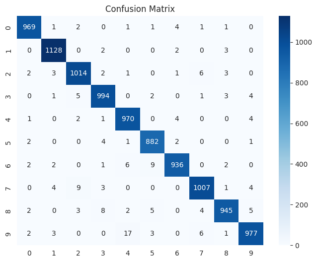

```
              precision    recall  f1-score   support

           0       0.99      0.99      0.99       980
           1       0.99      0.99      0.99      1135
           2       0.98      0.98      0.98      1032
           3       0.98      0.98      0.98      1010
           4       0.97      0.99      0.98       982
           5       0.98      0.99      0.98       892
           6       0.99      0.98      0.98       958
           7       0.98      0.98      0.98      1028
           8       0.99      0.97      0.98       974
           9       0.98      0.97      0.98      1009

    accuracy                           0.98     10000
   macro avg       0.98      0.98      0.98     10000
weighted avg       0.98      0.98      0.98     10000
```

```python
from sklearn.metrics import confusion_matrix, classification_report
import seaborn as sns

cm = confusion_matrix(true_labels, predicted_labels)
plt.figure(figsize=(8, 6))
sns.heatmap(cm, annot=True, cmap='Blues', fmt='d')
plt.title("Confusion Matrix")
plt.show()

print(classification_report(true_labels, predicted_labels))
```

**Conclusion:-**

The Handwritten Digit Recognition using Neural Networks project successfully demonstrated how deep learning can accurately classify handwritten digits from the MNIST dataset. Through data preprocessing, normalization, and training a feedforward neural network with dropout layers, the model achieved high accuracy and strong generalization on unseen data. The evaluation metrics, including precision, recall, and F1-scores, indicate that the model performs consistently well across all digit classes, with minimal misclassification. This project highlights the effectiveness of neural networks for image-based classification tasks and serves as a strong foundation for more advanced computer vision applications such as document digitization, automated form reading, and optical character recognition (OCR) systems.